# Coral Reef Problem Set

### **Questions 4&5:**

```r
## Loading required package: deSolve
require(deSolve)
```

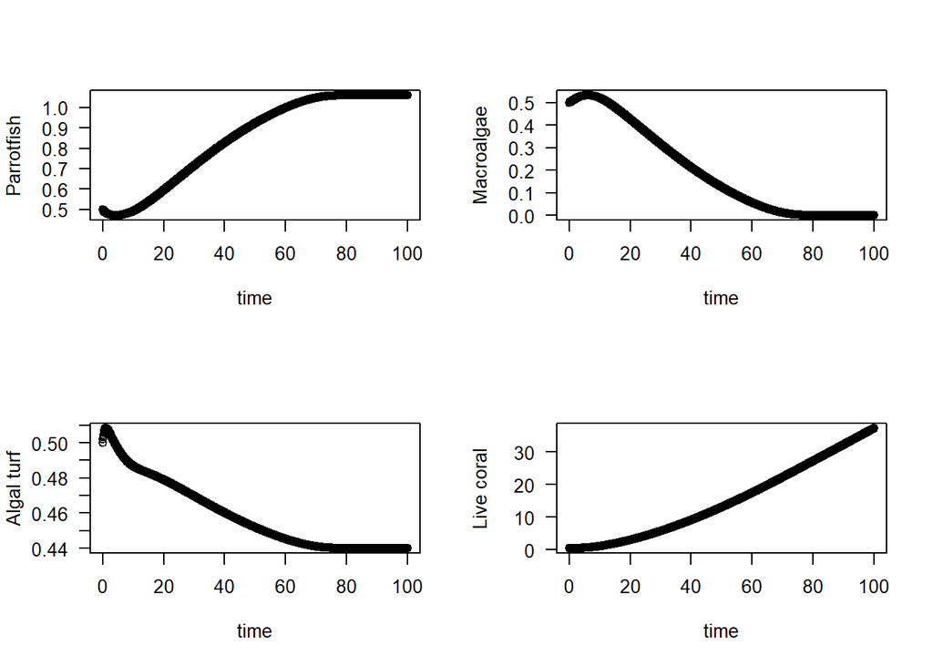

```r
# Initial values
state <- c(P = 0.5, M = 0.5, TA = 0.5, C = 0.5)
times <- seq(0, 100,by=0.1)

# Parameters
parameters <- c(a = 0.1,g = 0.8, r = 1.0,d = 0.44,s = 0.49)

# Model
reef <- function(t,state,parameters){
  with(as.list(c(state,parameters)),{
       dM <- (a*M*C) - ((P*M)/(M+TA)) + (g*M*TA)
       dC <- (r*TA*C) - (d*C) - (a*M*C)
       dT <- ((P*M)/(M+TA)) - (g*M*TA) - (r*TA*C) + (d*C)
       dP <- s*P*(1 - (P/C))
       list(c(dM, dC, dT, dP))
  })}

# Solve model and plot results
out <- ode(y = state,times=times,func=reef,parms=parameters)
par(mfrow=c(2,2))
plot(out[,1],out[,2],ylab='Parrotfish',xlab='time',las=1)
plot(out[,1],out[,3],ylab='Macroalgae',xlab='time',las=1)
plot(out[,1],out[,4],ylab='Algal turf',xlab='time',las=1)
plot(out[,1],out[,5],ylab='Live coral',xlab='time',las=1)
```

*(a)* From these models it is apparent that in the long term increase in parrotfish populations ultimately has a positive impact on coral populations. Across time we see that both the parrot fish and coral populations increase while the algal turf and macroalgae but decrease. Eventually, the parrotfish population reaches carrying capacity and levels out. The decline in algal turf also seems to slow suggesting that some baseline level of turf will continue to exist in order to sustain the parrot fish population. Within the 100 year time frame, coral populations do not seem to be slowing in their growth rate, while Macroalgae are virtually non-existent.

*(b)*

The competition rate between macroalgae and coral (*a*) seems to be one of the most important parameters as it determines that corals ability to outcompete the macroalgae. Further the predation of parrotfish on both macroalgae and algal turf are crucial as this improves the competitive advantage of the coral. The harmony between the Algal turf population and the parrotfish carrying capacity also ensures that this predation dynamic is persistent across future generations.